# Quantium Virtual Internship - Retail Strategy and Analytics - Task 1

### Examining customer data

Now that we are happy with the transaction dataset, let’s have a look at the customer dataset.

```r
#### Examining customer data
head(customerData)
```

| LYLTY_CARD_NBR | LIFESTAGE | PREMIUM_CUSTOMER |
| --- | --- | --- |
| 1000 | YOUNG SINGLES/COUPLES | Premium |
| 1002 | YOUNG SINGLES/COUPLES | Mainstream |
| 1003 | YOUNG FAMILIES | Budget |
| 1004 | OLDER SINGLES/COUPLES | Mainstream |
| 1005 | MIDAGE SINGLES/COUPLES | Mainstream |
| 1007 | YOUNG SINGLES/COUPLES | Budget |

```r
summary(customerData)
```

```
##  LYLTY_CARD_NBR     LIFESTAGE         PREMIUM_CUSTOMER
##  Min.   :   1000   Length:72637       Length:72637
##  1st Qu.:  66202   Class :character   Class :character
##  Median : 134040   Mode  :character   Mode  :character
##  Mean   : 136186
##  3rd Qu.: 203375
##  Max.   :2373711
```

```r
customerData[, .N, LIFESTAGE][order(-N)]
```

| LIFESTAGE | N |
| --- | --- |
| RETIREES | 14805 |
| OLDER SINGLES/COUPLES | 14609 |
| YOUNG SINGLES/COUPLES | 14441 |
| OLDER FAMILIES | 9780 |
| YOUNG FAMILIES | 9178 |
| MIDAGE SINGLES/COUPLES | 7275 |
| NEW FAMILIES | 2549 |

```r
customerData[, .N, PREMIUM_CUSTOMER][order(-N)]
```

| PREMIUM_CUSTOMER | N |
| --- | --- |
| Mainstream | 29245 |
| Budget | 24470 |
| Premium | 18922 |

```r
#### Merge transaction data to customer data
data <- merge(transactionData, customerData, all.x = TRUE)
```

Let’s also check if some customers were not matched on by checking for nulls.

```r
lapply(data, function(x)sum(is.na(x)))
```

```
## $LYLTY_CARD_NBR
## [1] 0
##
## $DATE
## [1] 0
##
## $STORE_NBR
## [1] 0
##
## $TXN_ID
## [1] 0
##
## $PROD_NBR
## [1] 0
##
## $PROD_NAME
## [1] 0
##
## $PROD_QTY
## [1] 0
##
## $TOT_SALES
## [1] 0
##
## $PACK_SIZE
## [1] 0
##
## $BRAND
## [1] 0
##
## $LIFESTAGE
## [1] 0
##
## $PREMIUM_CUSTOMER
## [1] 0
```

Great, there are no nulls! So all our customers in the transaction data has been accounted for in the customer dataset.

```r
fwrite(data, paste0(filePath,"QVI_data.csv"))
```

## Data analysis on customer segments

Let’s start with calculating total sales by LIFESTAGE and PREMIUM_CUSTOMER and plotting the split by these segments to describe which customer segment contribute most to chip sales.

```r
#### Total sales by LIFESTAGE and PREMIUM_CUSTOMER
(sales <- data[, .(TOT_SALES = sum(TOT_SALES)), .(LIFESTAGE, PREMIUM_CUSTOMER)][order(-TOT_SALES)])
```

| LIFESTAGE | PREMIUM_CUSTOMER | TOT_SALES |
| --- | --- | --- |
| OLDER FAMILIES | Budget | 156863.75 |
| YOUNG SINGLES/COUPLES | Mainstream | 147582.20 |
| RETIREES | Mainstream | 145168.95 |
| YOUNG FAMILIES | Budget | 129717.95 |
| OLDER SINGLES/COUPLES | Budget | 127833.60 |
| OLDER SINGLES/COUPLES | Mainstream | 124648.50 |
| OLDER SINGLES/COUPLES | Premium | 123537.55 |
| RETIREES | Budget | 105916.30 |
| OLDER FAMILIES | Mainstream | 96413.55 |
| RETIREES | Premium | 91296.65 |

[output cut: 11 more lines]

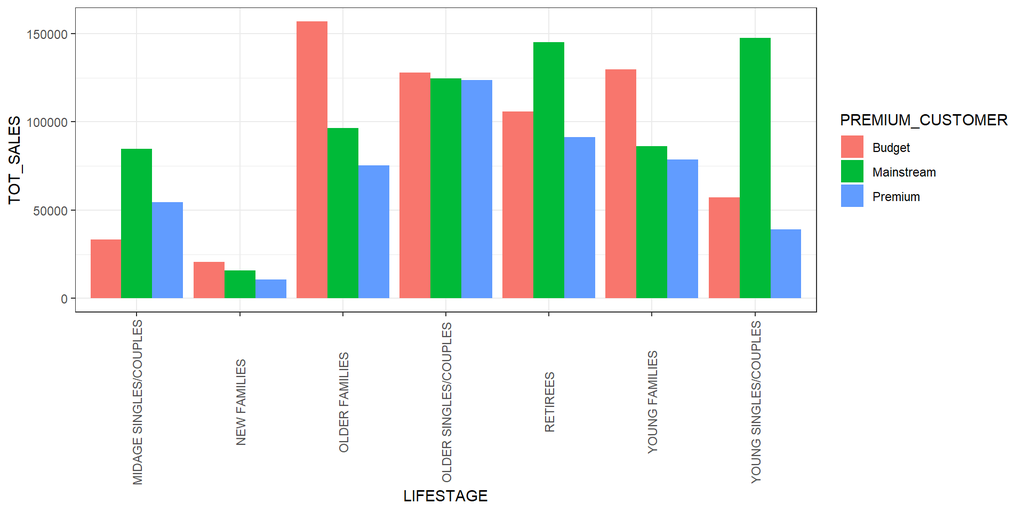

```r
ggplot(sales, aes(x = LIFESTAGE, y = TOT_SALES, fill = PREMIUM_CUSTOMER))+
  geom_col(position = "dodge")+
  theme(axis.text.x = element_text(angle = 90, vjust = 0.5))
```

Sales are coming mainly from Budget - older families, Mainstream - young singles/couples, and Mainstream - retirees

Let’s see if the higher sales are due to there being more customers who buy chips.

```r
#### Number of customers by LIFESTAGE and PREMIUM_CUSTOMER
(customer <- data[, .(TOT_CUSTOMER=uniqueN(LYLTY_CARD_NBR)), .(LIFESTAGE, PREMIUM_CUSTOMER)][order(-TOT_CUSTOMER)])
```

| LIFESTAGE | PREMIUM_CUSTOMER | TOT_CUSTOMER |
| --- | --- | --- |
| YOUNG SINGLES/COUPLES | Mainstream | 7917 |
| RETIREES | Mainstream | 6358 |
| OLDER SINGLES/COUPLES | Mainstream | 4858 |
| OLDER SINGLES/COUPLES | Budget | 4849 |
| OLDER SINGLES/COUPLES | Premium | 4682 |
| OLDER FAMILIES | Budget | 4611 |
| RETIREES | Budget | 4385 |
| YOUNG FAMILIES | Budget | 3953 |
| RETIREES | Premium | 3812 |
| YOUNG SINGLES/COUPLES | Budget | 3647 |

[output cut: 11 more lines]

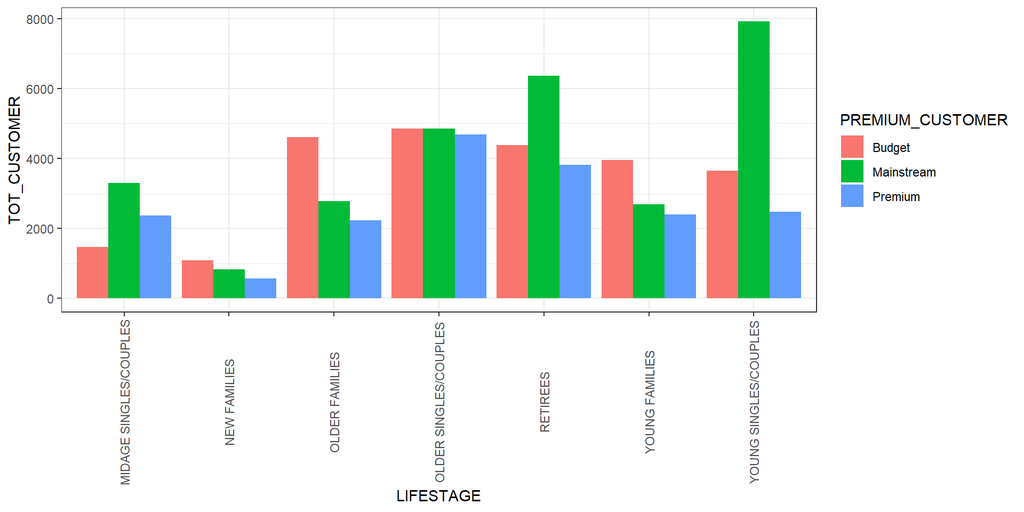

```r
ggplot(customer, aes(x = LIFESTAGE, y = TOT_CUSTOMER, fill = PREMIUM_CUSTOMER))+
  geom_col(position = "dodge")+
  theme(axis.text.x = element_text(angle = 90, vjust = 0.5))
```

There are more Mainstream - young singles/couples and Mainstream - retirees who buy chips. This contributes to there being more sales to these customer segments but this is not a major driver for the Budget - Older families segment.

Higher sales may also be driven by more units of chips being bought per customer. Let’s have a look at this next.

```r
#### Average number of units per customer by LIFESTAGE and PREMIUM_CUSTOMER
(units <- data[, .(AVG_UNITS=sum(PROD_NBR) / uniqueN(LYLTY_CARD_NBR)), .(LIFESTAGE, PREMIUM_CUSTOMER)][order(-AVG_UNITS)])
```

| LIFESTAGE | PREMIUM_CUSTOMER | AVG_UNITS |
| --- | --- | --- |
| OLDER FAMILIES | Mainstream | 268.5430 |
| OLDER FAMILIES | Premium | 264.8861 |
| OLDER FAMILIES | Budget | 262.3763 |
| YOUNG FAMILIES | Budget | 255.7463 |
| YOUNG FAMILIES | Mainstream | 255.7400 |
| YOUNG FAMILIES | Premium | 254.3349 |
| OLDER SINGLES/COUPLES | Budget | 199.5490 |
| OLDER SINGLES/COUPLES | Mainstream | 198.8720 |
| OLDER SINGLES/COUPLES | Premium | 197.9374 |
| MIDAGE SINGLES/COUPLES | Mainstream | 186.5919 |

[output cut: 11 more lines]

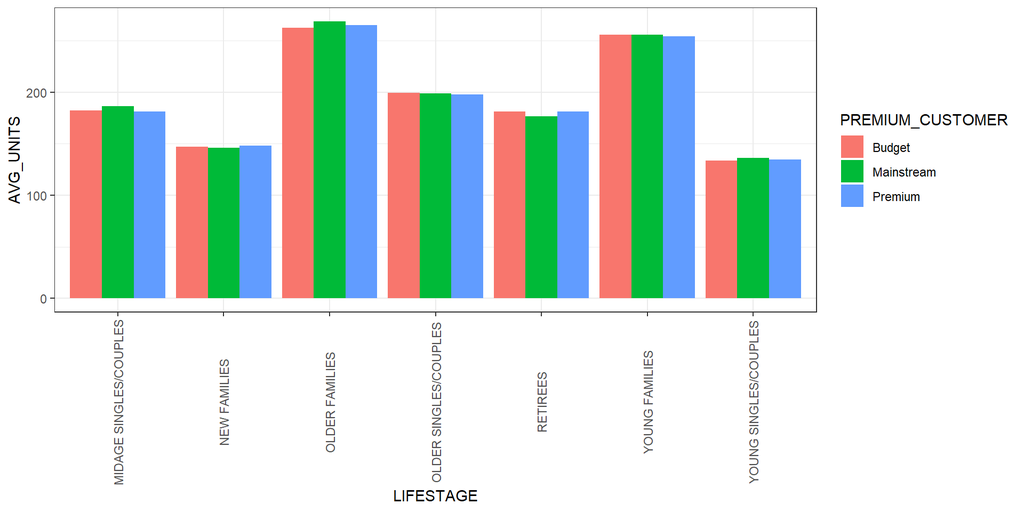

```r
ggplot(units, aes(x = LIFESTAGE, y = AVG_UNITS, fill = PREMIUM_CUSTOMER))+
  geom_col(position = "dodge")+
  theme(axis.text.x = element_text(angle = 90, vjust = 0.5))
```

Let’s also investigate the average price per unit chips bought for each customer segment as this is also a driver of total sales.

```r
#### Average price per unit by LIFESTAGE and PREMIUM_CUSTOMER
(price <- data[, .(AVG_PRICE=sum(TOT_SALES)/sum(PROD_NBR)), .(LIFESTAGE, PREMIUM_CUSTOMER)][order(-AVG_PRICE)])
```

| LIFESTAGE | PREMIUM_CUSTOMER | AVG_PRICE |
| --- | --- | --- |
| MIDAGE SINGLES/COUPLES | Mainstream | 0.1376942 |
| YOUNG SINGLES/COUPLES | Mainstream | 0.1367453 |
| OLDER SINGLES/COUPLES | Premium | 0.1333029 |
| RETIREES | Budget | 0.1331962 |
| RETIREES | Premium | 0.1322745 |
| OLDER SINGLES/COUPLES | Budget | 0.1321123 |
| NEW FAMILIES | Mainstream | 0.1318979 |
| OLDER FAMILIES | Budget | 0.1296591 |
| RETIREES | Mainstream | 0.1294106 |
| OLDER SINGLES/COUPLES | Mainstream | 0.1290197 |

[output cut: 11 more lines]

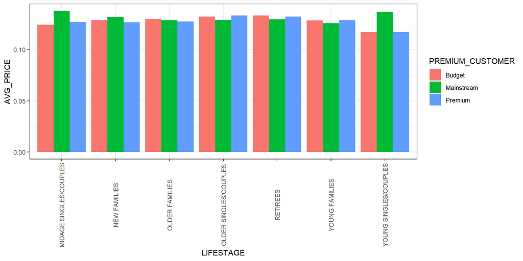

```r
ggplot(price, aes(x = LIFESTAGE, y = AVG_PRICE, fill = PREMIUM_CUSTOMER))+
  geom_col(position = "dodge")+
  theme(axis.text.x = element_text(angle = 90, vjust = 0.5))
```

As the difference in average price per unit isn’t large, we can check if this difference is statistically different.

```r
#### Perform an independent t-test between mainstream vs premium and budget midage and
#### young singles and couples
mainstream <- data[LIFESTAGE %in% c("YOUNG SINGLES/COUPLES", "MIDAGE SINGLES/COUPLES") & PREMIUM_CUSTOMER == "Mainstream", TOT_SALES/PROD_QTY]
premium_and_budget <- data[LIFESTAGE %in% c("YOUNG SINGLES/COUPLES", "MIDAGE SINGLES/COUPLES") & PREMIUM_CUSTOMER != "Premium", TOT_SALES/PROD_QTY]
t.test(mainstream, premium_and_budget)
```

```
##
##  Welch Two Sample t-test
##
## data:  mainstream and premium_and_budget
## t = 13.902, df = 67402, p-value < 2.2e-16
## alternative hypothesis: true difference in means is not equal to 0
## 95 percent confidence interval:
##  0.09135741 0.12134651
## sample estimates:
## mean of x mean of y
##  4.039786  3.933434
```

## Deep dive into specific customer segments for insights

We have found quite a few interesting insights that we can dive deeper into.

We might want to target customer segments that contribute the most to sales to retain them or further increase sales. Let’s look at Mainstream - young singles/couples. For instance, let’s find out if they tend to buy a particular brand of chips.

```r
#### Deep dive into Mainstream, young singles/couples
# Over to you! Work out of there are brands that these two customer segments prefer more than others. You could use a technique called affinity analysis or a-priori analysis (or any other method if you prefer)
segment1 <- data[LIFESTAGE == "YOUNG SINGLES/COUPLES" & PREMIUM_CUSTOMER == "Mainstream",]
segment2 <- data[!(LIFESTAGE == "YOUNG SINGLES/COUPLES" & PREMIUM_CUSTOMER == "Mainstream"),]

Total1 <- segment1[, sum(PROD_QTY)]
Total2 <- segment2[, sum(PROD_QTY)]

Total1_BRAND <- segment1[, .(targetSegment = sum(PROD_QTY)/Total1), BRAND]
Total2_BRAND <- segment2[, .(Other = sum(PROD_QTY)/Total2), BRAND]

(merge(Total1_BRAND, Total2_BRAND, by='BRAND')[, Affinity := targetSegment/Other])[order(-Affinity)]
```

| BRAND | targetSegment | Other | Affinity |
| --- | --- | --- | --- |
| TYRRELLS | 0.031552795 | 0.025692464 | 1.2280953 |
| TWISTIES | 0.046183575 | 0.037876520 | 1.2193194 |
| DORITOS | 0.122760524 | 0.101074684 | 1.2145526 |
| KETTLE | 0.197984817 | 0.165553442 | 1.1958967 |
| TOSTITOS | 0.045410628 | 0.037977861 | 1.1957131 |
| PRINGLES | 0.119420290 | 0.100634769 | 1.1866703 |
| COBS | 0.044637681 | 0.039048861 | 1.1431238 |
| INFUZIONS | 0.064679089 | 0.057064679 | 1.1334347 |
| THINS | 0.060372671 | 0.056986370 | 1.0594230 |
| GRNWVES | 0.032712215 | 0.031187957 | 1.0488733 |

[output cut: 10 more lines]

We can see that young singles/couples trend to buy brands such as TYRRELLS, TWISTIES, and DORITOS than others.

Let’s also find out if our target segment tends to buy larger packs of chips.

```r
#### Preferred pack size compared to the rest of the population
Total1_BRAND <- segment1[, .(targetSegment = sum(PROD_QTY)/Total1), PACK_SIZE]
Total2_BRAND <- segment2[, .(Other = sum(PROD_QTY)/Total2), PACK_SIZE]

(merge(Total1_BRAND, Total2_BRAND, by='PACK_SIZE')[, Affinity := targetSegment/Other])[order(-Affinity)]
```

| PACK_SIZE | targetSegment | Other | Affinity |
| --- | --- | --- | --- |
| 270 | 0.031828847 | 0.025095929 | 1.2682873 |
| 380 | 0.032160110 | 0.025584213 | 1.2570295 |
| 330 | 0.061283644 | 0.050161917 | 1.2217166 |
| 134 | 0.119420290 | 0.100634769 | 1.1866703 |
| 110 | 0.106280193 | 0.089791190 | 1.1836372 |
| 210 | 0.029123533 | 0.025121265 | 1.1593180 |
| 135 | 0.014768806 | 0.013075403 | 1.1295106 |
| 250 | 0.014354727 | 0.012780590 | 1.1231662 |
| 170 | 0.080772947 | 0.080985964 | 0.9973697 |
| 150 | 0.157598344 | 0.163420656 | 0.9643722 |

[output cut: 10 more lines]

Our target group tends to buy package sizes like 270g, 380g and 330g, indicating that they prefer larger package sizes compared to the rest of the population.